# Lasso v.s. Lasso projection

- Show All Code
- Hide All Code
- View Source

Author

Affiliation

Ruxin Shi

Michigan State University, Statistics and Probability

Published

2024-04-16 18:38:50 EDT

Modified

2024-04-16 18:38:38 EDT

# 1 Simulation

This section provides the codes used to simulate the results.

## 1.1 Define Global Options

Global R chunk options are defined in the YAML header but local chunk options will over-ride global options. We can temporarily disable an individual chunk by inserting `#| eval = FALSE` on a line at the top of the chunk. The method for creating a `cfsize` option that controls font size in code chunks and their text output is based on an answer to a question posted on [stackoverflow.com](https://stackoverflow.com/a/46526740).

````markdown
```{r}
#| label: global-options
#| cfsize: footnotesize

# Create a custom chunk hook/option for controlling font size in chunk & output.
# Global value for this is set in YAML header.
def.chunk.hook  <- knitr::knit_hooks$get("chunk")
knitr::knit_hooks$set(chunk = function(x, options) {
  x <- def.chunk.hook(x, options)
  ifelse(options$cfsize != "normalsize",
         paste0("\n \\", options$cfsize,"\n\n", x, "\n\n \\normalsize"),
         x)
  })
```
````

## 1.2 Load Packages

Load R packages that we need to get additional functions.

````markdown
```{r}
#| label: load-packages

library(ivreg)
library(MASS)
library(ggplot2)
library(hdi)
```
```{r}
#| label: load-packages

library(glmnet)
```
```{r}
#| label: load-packages

library(dplyr)
```
```{r}
#| label: load-packages

library(qqman)
```
````

```
For example usage please run: vignette('qqman')
```

```
Citation appreciated but not required:
```

```
Turner, (2018). qqman: an R package for visualizing GWAS results using Q-Q and manhattan plots. Journal of Open Source Software, 3(25), 731, https://doi.org/10.21105/joss.00731.
```

````markdown
```{r}
#| label: load-packages

library(screening)
library(foreach)
library(doParallel)
```
```{r}
#| label: load-packages

library(kableExtra)
```
```{r}
#| label: load-packages

library(quarto)           # for quarto_version()
library(gridExtra)
```
```{r}
#| label: load-packages

library(patchwork)
```
````

## 1.3 Setting

The chunk below shows the settings.

````markdown
```{r}
#| label: setting
#| eval: true
weightcal=function(weight){
  len=length(weight)
  a=(weight>=0)
  b=abs(weight)/sum(abs(weight))
  c=NULL
  for(i in 1:len){
    if(a[i])c[i]=b[i]
    if(!a[i])c[i]=-1*b[i]
  }
  return(c)
}
#Y outcome, D exposure
#Z instruments, X covariates
J=300 #number of SNPs
J1=5 #useful SNPs
N=1000 #sample size
MAF=0.3 #minor allele frequency
Times=1000
Split=50
sig=0.08
squareh=0.2
ratio=c(0.4,0.4,0.1,0.05,0.05)#weights of SNPs
beta=c(-0.08,0,0.08) #causal effect
k=2#2-fold
```
````

## 1.4 Simulation

The chunk below shows the simulation process of MR-SPLIT with lasso projection.

````markdown
```{r}
#| label: simulate_MR_SPLIT
#| eval: false
set.seed(2)
cl <- makeCluster(50)
registerDoParallel(cl)

#tt1=Sys.time()
    for(jj in 1:3){
        results <- foreach(t=1:Times, .combine=rbind, .packages=c('ivreg','MASS','glmnet','screening','ivmodel')) %dopar% {
          set.seed(t)
          G=matrix(0,nrow=N,ncol=J)
          for(i in 1:J){
            maf=MAF[i%%length(MAF)]
            if(i%%length(MAF)==0)maf=MAF[length(MAF)]
            GG1=runif(N,min=0,max=1)
            GG1[GG1<=(1-maf)^2]=0
            GG1[GG1>(1-maf^2)]=2
            GG1[which(GG1!=0&GG1!=2)]=1
            G[,i]=GG1
          }
          Sigma=matrix(c(5,sig,sig,5),nrow=2,ncol=2)
          sumsquarepi=squareh*Sigma[2,2]/(1-squareh)/(2*MAF*(1-MAF))
          pi0=sqrt(sumsquarepi*ratio)
          error=mvrnorm(N,mu=c(0,0),Sigma=Sigma)
          real=sample(c(1:J),size=J1,replace = FALSE)
          Greal=G[,real]
          X=as.matrix(Greal)%*%as.matrix(pi0)+error[,1]
          Y=X*beta[jj]+error[,2]

          #split sample
          selected=NULL
          unselected=1:N
          n=sample(unselected,size=N/k,replace = FALSE)
          selected=cbind(selected,n)
          for(p in 1:k){
            if(p<k){
              n=sample(unselected[-selected],size=N/k,replace = FALSE)
              selected=cbind(selected,n)
            }
          }
          #select IVs using SIS
          selectIV=list()
          for(p in 1:k){
            n=selected[,p]
            if(J<N/2){
              fit=screening(G[-n,],X[-n],method = "sis",num.select = 100)
            }
            if(J>N/2){
              fit=screening(G[-n,],X[-n],method = "sis")
            }
            selectIV[[p]]=fit$screen
          }
          #LASSO
          weights=list()
          for(p in 1:k){
            n=selected[,p]
            C=lasso.proj(x=G[-n,selectIV[[p]]],y=X[-n])
            selectIV[[p]]=selectIV[[p]][C$pval<=0.05]

            lasso.fit=lm(X[-n]~G[-n,selectIV[[p]]])
            weights[[p]]=summary(lasso.fit)$coef[-1,1]
          }

          #select major and weak based on partial F statistics
          partialF=list()
          for(p in 1:k){
            n=selected[,p]
            full=lm(X[-n]~G[-n,selectIV[[p]]])
            Fs=NULL
            if(length(selectIV[[p]])==1){
              Fs=summary(lm(X[-n]~G[-n,selectIV[[p]]]))$fstat[1]
            }
            if(length(selectIV[[p]])>1){
              for(q in 1:length(selectIV[[p]])){
                reduced=lm(X[-n]~G[-n,selectIV[[p]][-q]])
                Fs[q]=anova(reduced,full)$F[2]
              }
            }
            partialF[[p]]=Fs
          }

          num.major=NULL
          num.weak=NULL
          selectmajorF30=list()
          selectweakF30=list()

          for(p in 1:k){
            selectmajorF30[[p]]=selectIV[[p]][partialF[[p]]>=30]
            selectweakF30[[p]]=selectIV[[p]][partialF[[p]]<30]
            num.major=c(num.major,sum(partialF[[p]]>=30))
            num.weak=c(num.weak,sum(partialF[[p]]<30))
          }

          #Get coef1
          combineMajor1=list()
          for(p in 1:k){
            n=selected[,p]
            weakwei1=weights[[p]][partialF[[p]]<30]
            if(length(weakwei1)>1){
              weakwei1=weightcal(weakwei1)
              combineMajor1[[p]]=cbind(G[n,selectmajorF30[[p]]],G[n,selectweakF30[[p]]]%*%weakwei1)
            }
            if(length(weakwei1)<=1) combineMajor1[[p]]=G[n,selectIV[[p]]]
          }

          #MAJOR1
          hatX=NULL
          for(p in 1:k){
            n=selected[,p]
            fit=lm(X[n]~combineMajor1[[p]])
            hatX=c(hatX,fit$fitted.values)
          }
          fit2=lm(Y[c(selected)]~hatX)
          Major.all1=matrix(NA,ncol=4,nrow=Split)
          Major.all1[1,]=c(summary(fit2)$coef[2,1:4])

          for(S in 2:Split){
            selected=NULL
            unselected=1:N
            n=sample(unselected,size=N/k,replace = FALSE)
            selected=cbind(selected,n)
            for(p in 1:k){
              if(p<k){
                n=sample(unselected[-selected],size=N/k,replace = FALSE)
                selected=cbind(selected,n)
              }
            }
            #select IVs using SIS
            selectIV=list()
            for(p in 1:k){
              n=selected[,p]
              if(J<N/2){
                fit=screening(G[-n,],X[-n],method = "sis",num.select = 100)
              }
              if(J>N/2){
                fit=screening(G[-n,],X[-n],method = "sis")
              }
              selectIV[[p]]=fit$screen
            }
            #LASSO
          weights=list()
          for(p in 1:k){
            n=selected[,p]
            C=lasso.proj(x=G[-n,selectIV[[p]]],y=X[-n])
            selectIV[[p]]=selectIV[[p]][C$pval<=0.05]

            lasso.fit=lm(X[-n]~G[-n,selectIV[[p]]])
            weights[[p]]=summary(lasso.fit)$coef[-1,1]
          }


            #select major and weak based on partial F statistics
            partialF=list()
            for(p in 1:k){
              n=selected[,p]
              full=lm(X[-n]~G[-n,selectIV[[p]]])
              Fs=NULL
              if(length(selectIV[[p]])==1){
                Fs=summary(lm(X[-n]~G[-n,selectIV[[p]]]))$fstat[1]
              }
              if(length(selectIV[[p]])>1){
                for(q in 1:length(selectIV[[p]])){
                  reduced=lm(X[-n]~G[-n,selectIV[[p]][-q]])
                  Fs[q]=anova(reduced,full)$F[2]
                }
              }
              partialF[[p]]=Fs
            }

            selectmajorF30=list()
            selectweakF30=list()

            for(p in 1:k){
              selectmajorF30[[p]]=selectIV[[p]][partialF[[p]]>=30]
              selectweakF30[[p]]=selectIV[[p]][partialF[[p]]<30]
               num.major=c(num.major,sum(partialF[[p]]>=30))
               num.weak=c(num.weak,sum(partialF[[p]]<30))

            }

            #Get coef1
            combineMajor1=list()
            for(p in 1:k){
              n=selected[,p]
              weakwei1=weights[[p]][partialF[[p]]<30]
              if(length(weakwei1)>1){
                weakwei1=weightcal(weakwei1)
                combineMajor1[[p]]=cbind(G[n,selectmajorF30[[p]]],G[n,selectweakF30[[p]]]%*%weakwei1)
              }
              if(length(weakwei1)<=1) combineMajor1[[p]]=G[n,selectIV[[p]]]
            }

            #MAJOR1
            hatX=NULL
            for(p in 1:k){
              n=selected[,p]
              fit=lm(X[n]~combineMajor1[[p]])
              hatX=c(hatX,fit$fitted.values)
            }
            fit2=lm(Y[c(selected)]~hatX)
            Major.all1=matrix(NA,ncol=4,nrow=Split)
            Major.all1[1,]=c(summary(fit2)$coef[2,1:4])
          }
          T1=mean(tan((0.5-Major.all1[,4])*pi))
          p1=0.5-atan(T1)/pi
          point.est1_t=c(mean(Major.all1[,1]),p1)


          return(c(point.est1_t,mean(num.major),mean(num.weak)))
        }
        write.table(results,file=paste0("results/lasso proj_jj",jj,".txt"))
      }

stopCluster(cl)
```
````

The chunk below shows the simulation process of MR-SPLIT with lasso.

````markdown
```{r}
#| label: simulate_MR_SPLIT_lasso
#| eval: false
set.seed(2)
cl <- makeCluster(50)
registerDoParallel(cl)

#tt1=Sys.time()
    for(jj in 1:3){
        results <- foreach(t=1:Times, .combine=rbind, .packages=c('ivreg','MASS','glmnet','screening','ivmodel','hdi')) %dopar% {
          set.seed(t)
          G=matrix(0,nrow=N,ncol=J)
          for(i in 1:J){
            maf=MAF[i%%length(MAF)]
            if(i%%length(MAF)==0)maf=MAF[length(MAF)]
            GG1=runif(N,min=0,max=1)
            GG1[GG1<=(1-maf)^2]=0
            GG1[GG1>(1-maf^2)]=2
            GG1[which(GG1!=0&GG1!=2)]=1
            G[,i]=GG1
          }
          Sigma=matrix(c(5,sig,sig,5),nrow=2,ncol=2)
          sumsquarepi=squareh*Sigma[2,2]/(1-squareh)/(2*MAF*(1-MAF))
          pi0=sqrt(sumsquarepi*ratio)
          error=mvrnorm(N,mu=c(0,0),Sigma=Sigma)
          real=sample(c(1:J),size=J1,replace = FALSE)
          Greal=G[,real]
          X=as.matrix(Greal)%*%as.matrix(pi0)+error[,1]
          Y=X*beta[jj]+error[,2]

          #split sample
          selected=NULL
          unselected=1:N
          n=sample(unselected,size=N/k,replace = FALSE)
          selected=cbind(selected,n)
          for(p in 1:k){
            if(p<k){
              n=sample(unselected[-selected],size=N/k,replace = FALSE)
              selected=cbind(selected,n)
            }
          }
          #select IVs using SIS
          selectIV=list()
          for(p in 1:k){
            n=selected[,p]
            if(J<N/2){
              fit=screening(G[-n,],X[-n],method = "sis",num.select = 100)
            }
            if(J>N/2){
              fit=screening(G[-n,],X[-n],method = "sis")
            }
            selectIV[[p]]=fit$screen
          }

            #LASSO
        weights=list()
        for(p in 1:k){
          n=selected[,p]
          #select IVs
          lambda=cv.glmnet(G[-n,selectIV[[p]]],X[-n],alpha=1)$lambda.min
          lasso=glmnet(G[-n,selectIV[[p]]],X[-n],lambda=lambda)
          #coef of all IVs
          a=coef(lasso)[-1,]
          weights[[p]]=a[a!=0]
          #selected IVs
          selectIV[[p]]=selectIV[[p]][a!=0]
        }

          #select major and weak based on partial F statistics
          partialF=list()
          for(p in 1:k){
            n=selected[,p]
            full=lm(X[-n]~G[-n,selectIV[[p]]])
            Fs=NULL
            if(length(selectIV[[p]])==1){
              Fs=summary(lm(X[-n]~G[-n,selectIV[[p]]]))$fstat[1]
            }
            if(length(selectIV[[p]])>1){
              for(q in 1:length(selectIV[[p]])){
                reduced=lm(X[-n]~G[-n,selectIV[[p]][-q]])
                Fs[q]=anova(reduced,full)$F[2]
              }
            }
            partialF[[p]]=Fs
          }

          num.major=NULL
          num.weak=NULL
          selectmajorF30=list()
          selectweakF30=list()

          for(p in 1:k){
            selectmajorF30[[p]]=selectIV[[p]][partialF[[p]]>=30]
            selectweakF30[[p]]=selectIV[[p]][partialF[[p]]<30]
            num.major=c(num.major,sum(partialF[[p]]>=30))
            num.weak=c(num.weak,sum(partialF[[p]]<30))
          }

          #Get coef1
          combineMajor1=list()
          for(p in 1:k){
            n=selected[,p]
            weakwei1=weights[[p]][partialF[[p]]<30]
            if(length(weakwei1)>1){
              weakwei1=weightcal(weakwei1)
              combineMajor1[[p]]=cbind(G[n,selectmajorF30[[p]]],G[n,selectweakF30[[p]]]%*%weakwei1)
            }
            if(length(weakwei1)<=1) combineMajor1[[p]]=G[n,selectIV[[p]]]
          }

          #MAJOR1
          hatX=NULL
          for(p in 1:k){
            n=selected[,p]
            fit=lm(X[n]~combineMajor1[[p]])
            hatX=c(hatX,fit$fitted.values)
          }
          fit2=lm(Y[c(selected)]~hatX)
          Major.all1=matrix(NA,ncol=4,nrow=Split)
          Major.all1[1,]=c(summary(fit2)$coef[2,1:4])

          for(S in 2:Split){
            selected=NULL
            unselected=1:N
            n=sample(unselected,size=N/k,replace = FALSE)
            selected=cbind(selected,n)
            for(p in 1:k){
              if(p<k){
                n=sample(unselected[-selected],size=N/k,replace = FALSE)
                selected=cbind(selected,n)
              }
            }
            #select IVs using SIS
            selectIV=list()
            for(p in 1:k){
              n=selected[,p]
              if(J<N/2){
                fit=screening(G[-n,],X[-n],method = "sis",num.select = 100)
              }
              if(J>N/2){
                fit=screening(G[-n,],X[-n],method = "sis")
              }
              selectIV[[p]]=fit$screen
            }
          #LASSO
        weights=list()
        for(p in 1:k){
          n=selected[,p]
          #select IVs
          lambda=cv.glmnet(G[-n,selectIV[[p]]],X[-n],alpha=1)$lambda.min
          lasso=glmnet(G[-n,selectIV[[p]]],X[-n],lambda=lambda)
          #coef of all IVs
          a=coef(lasso)[-1,]
          weights[[p]]=a[a!=0]
          #selected IVs
          selectIV[[p]]=selectIV[[p]][a!=0]
        }

            #select major and weak based on partial F statistics
            partialF=list()
            for(p in 1:k){
              n=selected[,p]
              full=lm(X[-n]~G[-n,selectIV[[p]]])
              Fs=NULL
              if(length(selectIV[[p]])==1){
                Fs=summary(lm(X[-n]~G[-n,selectIV[[p]]]))$fstat[1]
              }
              if(length(selectIV[[p]])>1){
                for(q in 1:length(selectIV[[p]])){
                  reduced=lm(X[-n]~G[-n,selectIV[[p]][-q]])
                  Fs[q]=anova(reduced,full)$F[2]
                }
              }
              partialF[[p]]=Fs
            }

            selectmajorF30=list()
            selectweakF30=list()

            for(p in 1:k){
              selectmajorF30[[p]]=selectIV[[p]][partialF[[p]]>=30]
              selectweakF30[[p]]=selectIV[[p]][partialF[[p]]<30]
               num.major=c(num.major,sum(partialF[[p]]>=30))
               num.weak=c(num.weak,sum(partialF[[p]]<30))

            }

            #Get coef1
            combineMajor1=list()
            for(p in 1:k){
              n=selected[,p]
              weakwei1=weights[[p]][partialF[[p]]<30]
              if(length(weakwei1)>1){
                weakwei1=weightcal(weakwei1)
                combineMajor1[[p]]=cbind(G[n,selectmajorF30[[p]]],G[n,selectweakF30[[p]]]%*%weakwei1)
              }
              if(length(weakwei1)<=1) combineMajor1[[p]]=G[n,selectIV[[p]]]
            }

            #MAJOR1
            hatX=NULL
            for(p in 1:k){
              n=selected[,p]
              fit=lm(X[n]~combineMajor1[[p]])
              hatX=c(hatX,fit$fitted.values)
            }
            fit2=lm(Y[c(selected)]~hatX)
            Major.all1=matrix(NA,ncol=4,nrow=Split)
            Major.all1[1,]=c(summary(fit2)$coef[2,1:4])
          }
          T1=mean(tan((0.5-Major.all1[,4])*pi))
          p1=0.5-atan(T1)/pi
          point.est1_t=c(mean(Major.all1[,1]),p1)


          return(c(point.est1_t,mean(num.major),mean(num.weak)))
        }
        write.table(results,file=paste0("results/lasso_jj",jj,".txt"))
      }

stopCluster(cl)
```
````

# 2 Results

## 2.1 Load data

````markdown
```{r fig.width=6, fig.height=3}
#setwd("C:/Users/shirx/OneDrive/Desktop/msu/research/Major/Simulation study/lasso")
aa=1
data_lasso=list()
for(jj in c(1:3)){
      file=paste0("results/lasso_jj",jj,".txt")
      data_lasso[[aa]]=read.table(file = file,header = TRUE)
      aa=aa+1
}
```
````

````markdown
```{r}
aa=1
data_lasso_proj=list()
for(jj in c(1:3)){
      file=paste0("results/lasso proj_jj",jj,".txt")
      data_lasso_proj[[aa]]=read.table(file = file,header = TRUE)
      aa=aa+1
}
```
````

## 2.2 Boxplots of Estimates

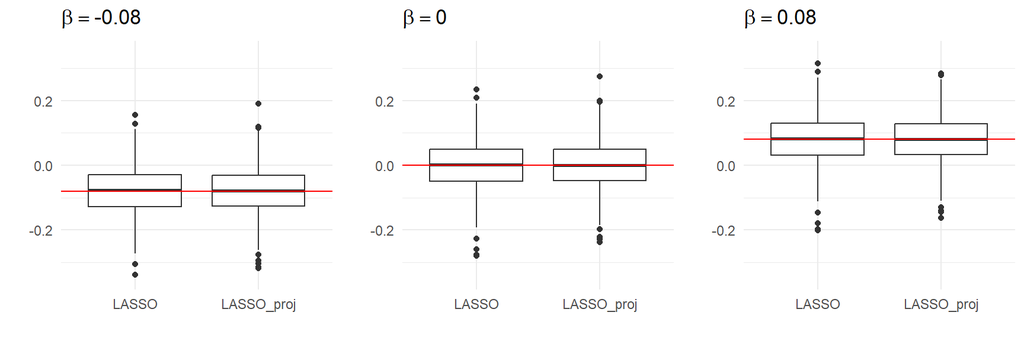

````markdown
```{r fig.width=9, fig.height=3}
# 用于排列多个图形

plots <- list()  # 创建一个列表来保存所有的ggplot对象

for(jj in 1:3) {
  data1 <- data_lasso[[jj]]
  data2 <- data_lasso_proj[[jj]]
  real.beta <- beta[jj]

  df <- data.frame(Value = c(data1[, 1], data2[, 1]),
                   Method = rep(c("LASSO", "LASSO_proj"), each = length(data1[, 1])))

  # 创建ggplot对象
  p <- ggplot(df, aes(x = Method, y = Value)) +
    geom_boxplot() +
    geom_hline(yintercept = real.beta, color = "red") +
    ylim(-0.35, 0.35) +
    labs(title = bquote(beta == .(real.beta)), y = "", x = "") +
    theme_minimal()

  plots[[jj]] <- p  # 将ggplot对象添加到列表中
}

# 使用grid.arrange()从gridExtra包排列所有图形
do.call(grid.arrange, c(plots, ncol = 3))
```
````

## 2.3 Comparison of type I error

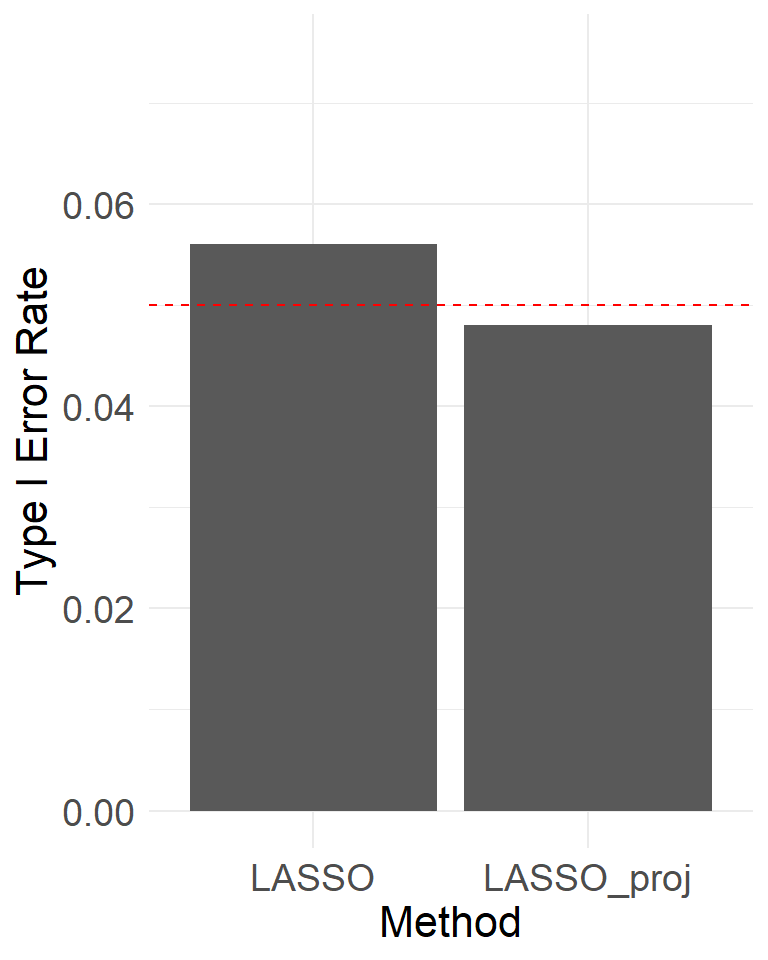

Comparison of Type I error between LASSO and LASSO.proj

````markdown
```{r fig.width=4, fig.height=5}
#| fig-cap: Comparison of Type I error between LASSO and LASSO.proj
#calculate type I error
jj=2
type.I.long <- data.frame(
  Method = rep(c("LASSO", "LASSO_proj"), each = 1),
  Value = c(sum(data_lasso[[jj]][,2]<0.05),sum(data_lasso_proj[[jj]][,2]<0.05))/1000
)

# Create a histogram using ggplot
ggplot(type.I.long, aes(x = Method, y = Value)) +
  geom_bar(stat = "identity", position = "dodge") +
  geom_hline(yintercept = 0.05, linetype = "dashed", color = "red") +
  ylim(0, 0.075) +
  labs(title = NULL, x = "Method", y = "Type I Error Rate") +
  theme_minimal()+
  theme(
    plot.title = element_text(size = 20),   # 调整主标题字体大小
    axis.title = element_text(size = 16),   # 调整轴标题字体大小
    axis.text = element_text(size = 14),    # 调整轴文本标签字体大小
    legend.title = element_text(size = 14), # 调整图例标题字体大小
    legend.text = element_text(size = 12)   # 调整图例文本标签字体大小
  )
```
````

## 2.4 Comparison of power

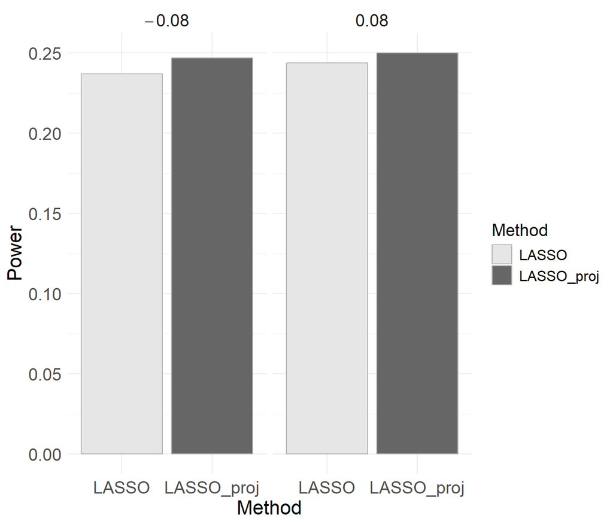

Comparison of power between LASSO and LASSO.proj

````markdown
```{r fig.width=7, fig.height=6}
#| fig-cap: Comparison of power between LASSO and LASSO.proj
#calculate power

power.long <- data.frame(
  Method = rep(c("LASSO", "LASSO_proj"), each = 1),
  Value = c(sum(data_lasso[[1]][,2]<0.05),sum(data_lasso_proj[[1]][,2]<0.05),sum(data_lasso[[3]][,2]<0.05),sum(data_lasso_proj[[3]][,2]<0.05))/1000,
  beta=c(rep(c(-0.08,0.08),each=2))
)

ggplot(power.long, aes(x = Method, y = Value, fill = Method)) +
  geom_bar(stat = "identity", position = position_dodge(), color = "#b3b3b3") +
  facet_wrap(~beta, labeller = labeller(beta = label_parsed)) +
  labs(x = "Method", y = "Power") +
  theme(plot.title = element_text(hjust = 0.5)) +
  scale_fill_manual(values = c("#e6e6e6", "#666666")) +  # 调整颜色以匹配数据
  theme_minimal()+
  theme(
    strip.text = element_text(size = 14),   # 调整分面标签字体大小
    plot.title = element_text(size = 20),   # 调整主标题字体大小
    axis.title = element_text(size = 16),   # 调整轴标题字体大小
    axis.text = element_text(size = 14),    # 调整轴文本标签字体大小
    legend.title = element_text(size = 14), # 调整图例标题字体大小
    legend.text = element_text(size = 12)   # 调整图例文本标签字体大小
  )
```
````

## 2.5 Comparison of RMSE

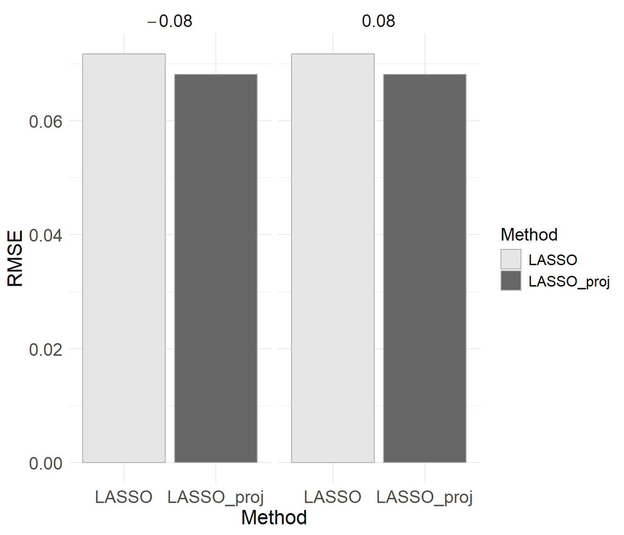

Comparison of RMSE between LASSO and LASSO.proj

````markdown
```{r fig.width=7, fig.height=6}
#| fig-cap: Comparison of RMSE between LASSO and LASSO.proj
#calculate RMSE

RMSE.long <- data.frame(
  Method = rep(c("LASSO", "LASSO_proj"), each = 1),
  Value = c(sqrt(mean((data_lasso[[1]][,1]-beta[1])^2)),sqrt(mean((data_lasso_proj[[1]][,1]-beta[1])^2)),sqrt(mean((data_lasso[[3]][,1]-beta[3])^2)),sqrt(mean((data_lasso_proj[[3]][,1]-beta[3])^2))),
  beta=c(rep(c(-0.08,0.08),each=2))
)

ggplot(RMSE.long, aes(x = Method, y = Value, fill = Method)) +
  geom_bar(stat = "identity", position = position_dodge(), color = "#b3b3b3") +
  facet_wrap(~beta, labeller = labeller(beta = label_parsed)) +
  labs(x = "Method", y = "RMSE") +
  theme(plot.title = element_text(hjust = 0.5)) +
  scale_fill_manual(values = c("#e6e6e6", "#666666")) +  # 调整颜色以匹配数据
  theme_minimal()+
  theme(
    strip.text = element_text(size = 14),   # 调整分面标签字体大小
    plot.title = element_text(size = 20),   # 调整主标题字体大小
    axis.title = element_text(size = 16),   # 调整轴标题字体大小
    axis.text = element_text(size = 14),    # 调整轴文本标签字体大小
    legend.title = element_text(size = 14), # 调整图例标题字体大小
    legend.text = element_text(size = 12)   # 调整图例文本标签字体大小
  )
```
````

## 2.6 IV selected

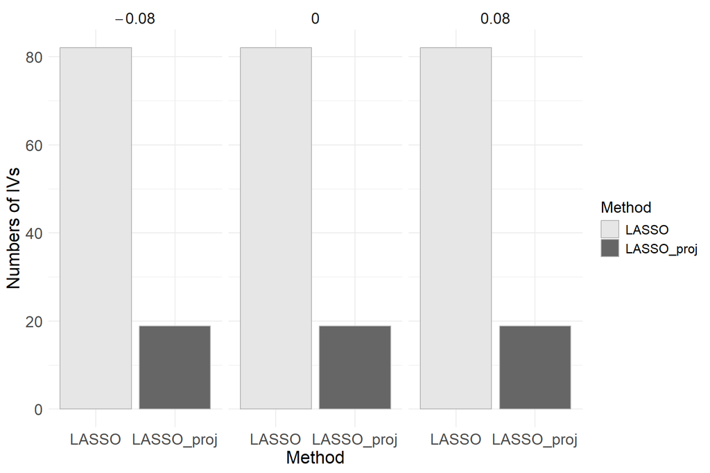

Comparison of numbers of IVs selected between LASSO and LASSO.proj

````markdown
```{r fig.width=9, fig.height=6}
#| fig-cap: Comparison of numbers of IVs selected between LASSO and LASSO.proj
#calculate numbers of IVs

Num_IV.long <- data.frame(
  Method = rep(c("LASSO", "LASSO_proj"), each = 1),
  Value = c(sum(data_lasso[[1]][,c(3:4)]),sum(data_lasso_proj[[1]][,c(3:4)]),sum(data_lasso[[2]][,c(3:4)]),sum(data_lasso_proj[[2]][,c(3:4)]),sum(data_lasso[[3]][,c(3:4)]),sum(data_lasso_proj[[3]][,c(3:4)]))/1000,
  beta=c(rep(c(-0.08,0,0.08),each=2))
)

ggplot(Num_IV.long, aes(x = Method, y = Value, fill = Method)) +
  geom_bar(stat = "identity", position = position_dodge(), color = "#b3b3b3") +
  facet_wrap(~beta, labeller = labeller(beta = label_parsed)) +
  labs(x = "Method", y = "Numbers of IVs") +
  theme(plot.title = element_text(hjust = 0.5)) +
  scale_fill_manual(values = c("#e6e6e6", "#666666")) +  # 调整颜色以匹配数据
  theme_minimal()+
  theme(
    strip.text = element_text(size = 14),   # 调整分面标签字体大小
    plot.title = element_text(size = 20),   # 调整主标题字体大小
    axis.title = element_text(size = 16),   # 调整轴标题字体大小
    axis.text = element_text(size = 14),    # 调整轴文本标签字体大小
    legend.title = element_text(size = 14), # 调整图例标题字体大小
    legend.text = element_text(size = 12)   # 调整图例文本标签字体大小
  )
```
````

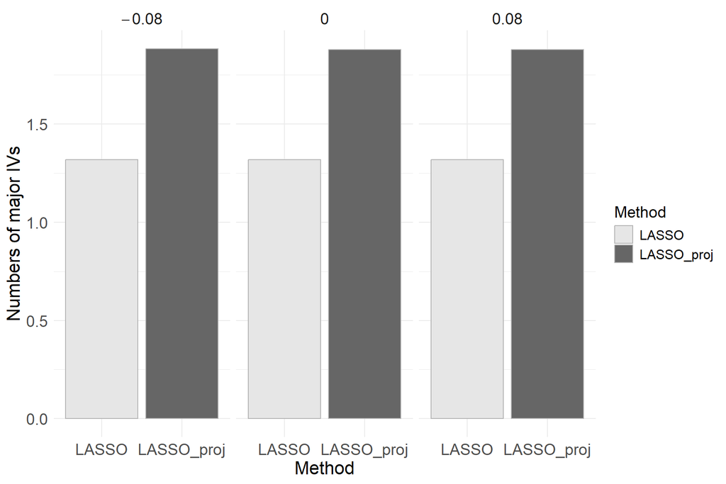

Comparison of numbers of major IVs selected between LASSO and LASSO.proj

````markdown
```{r fig.width=9, fig.height=6}
#| fig-cap: Comparison of numbers of major IVs selected between LASSO and LASSO.proj
#calculate numbers of IVs

Num_IV.long <- data.frame(
  Method = rep(c("LASSO", "LASSO_proj"), each = 1),
  Value = c(sum(data_lasso[[1]][,3]),sum(data_lasso_proj[[1]][,3]),sum(data_lasso[[2]][,3]),sum(data_lasso_proj[[2]][,3]),sum(data_lasso[[3]][,3]),sum(data_lasso_proj[[3]][,3]))/1000,
  beta=c(rep(c(-0.08,0,0.08),each=2))
)

ggplot(Num_IV.long, aes(x = Method, y = Value, fill = Method)) +
  geom_bar(stat = "identity", position = position_dodge(), color = "#b3b3b3") +
  facet_wrap(~beta, labeller = labeller(beta = label_parsed)) +
  labs(x = "Method", y = "Numbers of major IVs") +
  theme(plot.title = element_text(hjust = 0.5)) +
  scale_fill_manual(values = c("#e6e6e6", "#666666")) +  # 调整颜色以匹配数据
  theme_minimal()+
  theme(
    strip.text = element_text(size = 14),   # 调整分面标签字体大小
    plot.title = element_text(size = 20),   # 调整主标题字体大小
    axis.title = element_text(size = 16),   # 调整轴标题字体大小
    axis.text = element_text(size = 14),    # 调整轴文本标签字体大小
    legend.title = element_text(size = 14), # 调整图例标题字体大小
    legend.text = element_text(size = 12)   # 调整图例文本标签字体大小
  )
```
````

# 3 Software Information

This section documents information that is important for reproducibility. Most users will not need to read it. It is primarily here for use by the statistician on the team.

We used [R](https://www.r-project.org/) as our main computing environment and [Quarto](https://quarto.org/) scripts to enhance reproducibility. We used RStudio as the editor to interface with R and Quarto.

- Software chain: **qmd file > RStudio > Quarto > R > knitr > md file > Pandoc > html file**.
- Source file: **Lasso v.s. Lasso proj.qmd**
- Output file: **Lasso v.s. Lasso proj.html**
- [Quarto 1.4.544](https://quarto.org/) runs `*.qmd` files through [R](https://www.r-project.org/) and [knitr](https://yihui.org/knitr/) to produce `*.md` markdown files.
- [Pandoc 3.1.1](https://pandoc.org) converts markdown files (`*.md`) to other formats, including LaTeX (`*.tex`) and HTML (`*.html`) among others.

## 3.1 Versions